# Bios 6301: Assignment 3

Abdurrahman Abdulhamid

12/31/2022

50 points total.

Add your name as `author` to the file metadata section.

Submit a single knitr file (named `homework3.rmd`) by email to tianyi.sun@vanderbilt.edu. Place your R code in between the appropriate chunks for each question. Check your output by using the `Knit HTML` button in RStudio.

$5^{n=day}$ points taken off for each day late.

### Question 1

**15 points**

Write a simulation to calculate the power for the following study design. The study has two variables, treatment group and outcome. There are two treatment groups (0, 1) and they should be assigned randomly with equal probability. The outcome should be a random normal variable with a mean of 60 and standard deviation of 20. If a patient is in the treatment group, add 5 to the outcome. 5 is the true treatment effect. Create a linear model for the outcome by the treatment group, and extract the p-value (hint: see assigment1). Test if the p-value is less than or equal to the alpha level, which should be set to 0.05.

Repeat this procedure 1000 times. The power is calculated by finding the percentage of times the p-value is less than or equal to the alpha level. Use the `set.seed` command so that the professor can reproduce your results.

1.a. Find the power when the sample size is 100 patients. (10 points)

```r
set.seed(1000)
n_sims <- 1000 # we want 1000 simulations
p_vals <- c()
for(i in 1:n_sims){
  group1 <- rnorm(100,60,20) # simulate group 1
  group2 <- rnorm(100,65,25) # simulate group 2
  p_vals[i] <- t.test(group1, group2)$p.value # run t-test and extract the p-value
}
p_vals
```

[output not shown]

[output cut: 185 more lines]

```r
mean(p_vals <= .05) # check power (i.e. proportion of p-values that are smaller than alpha-level of .05)
```

```
## [1] 0.35
```

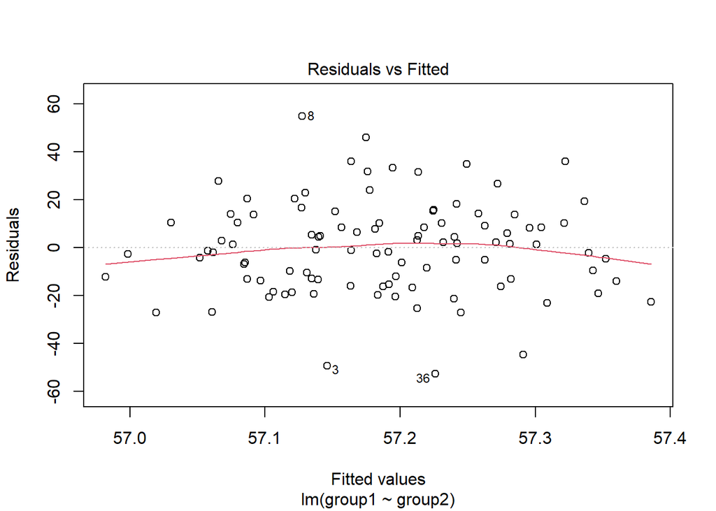

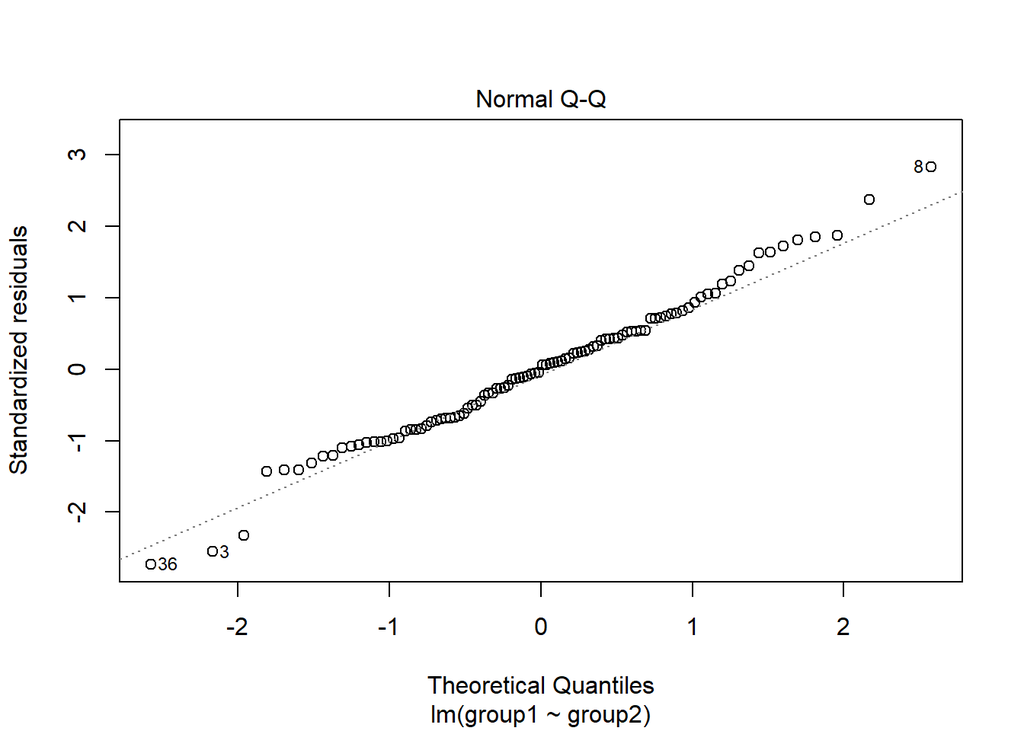

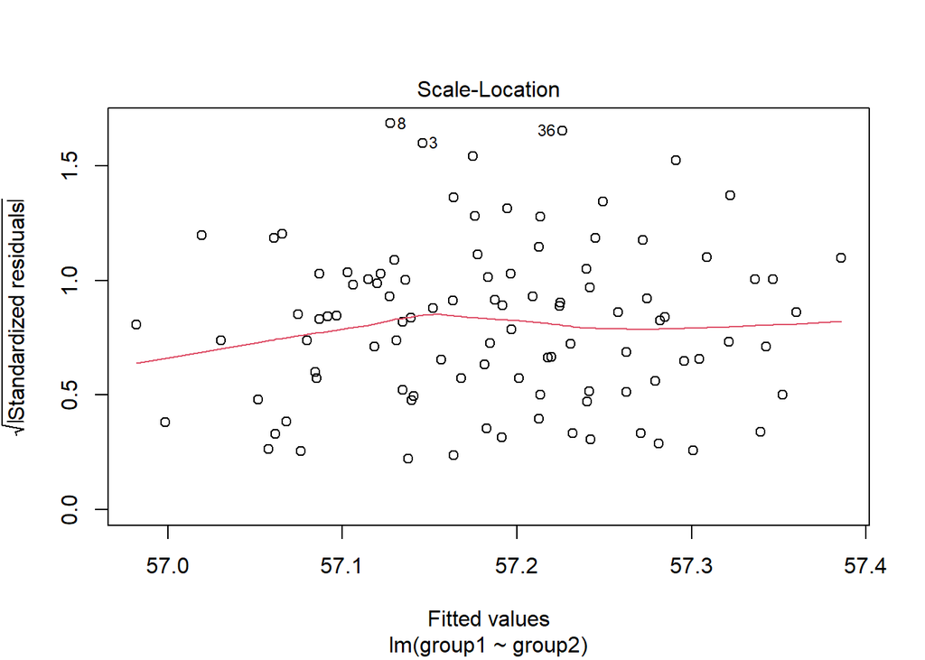

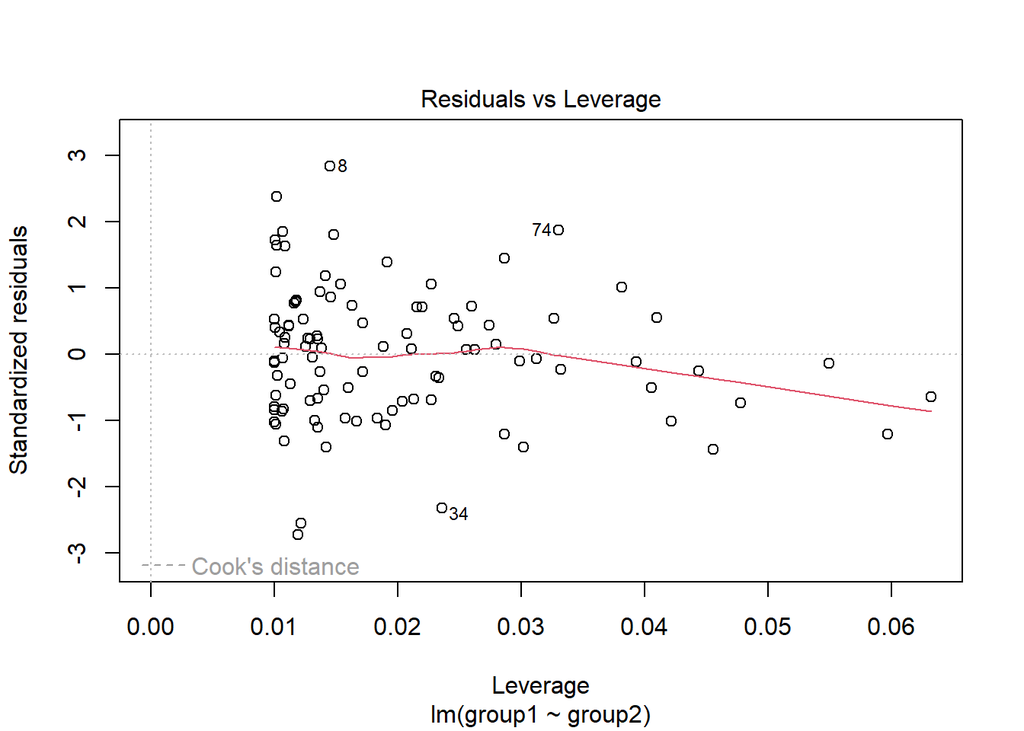

```r
Y<-lm(group1~group2)
plot(Y)
```

1.b. Find the power when the sample size is 1000 patients. (5 points)

```r
set.seed(1000)
n_sims <- 1000 # we want 1000 simulations
p_vals <- c()
for(i in 1:n_sims){
  group1 <- rnorm(1000,60,20) # simulate group 1
  group2 <- rnorm(1000,65,25) # simulate group 2
  p_vals[i] <- t.test(group1, group2)$p.value # run t-test and extract the p-value
}
p_vals
```

[output not shown]

[output cut: 185 more lines]

```r
mean(p_vals <= .05) # check power (i.e. proportion of p-values that are smaller than alpha-level of .05)
```

```
## [1] 1
```

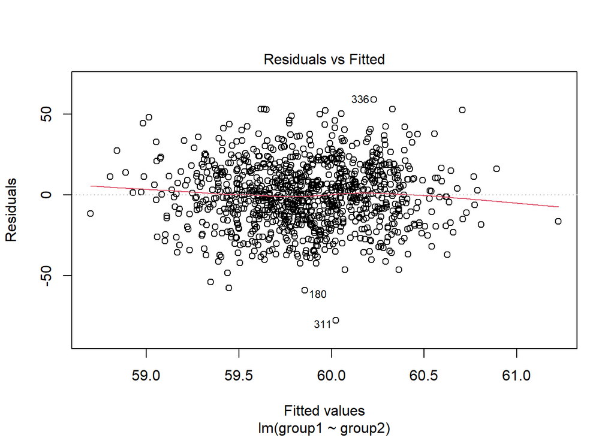

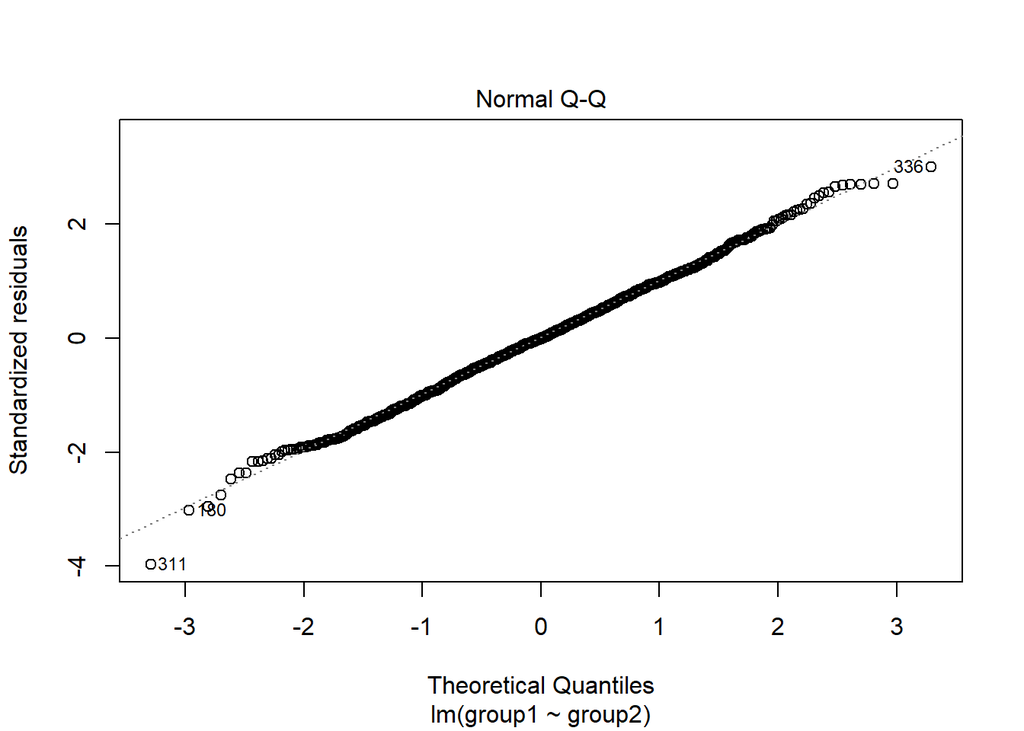

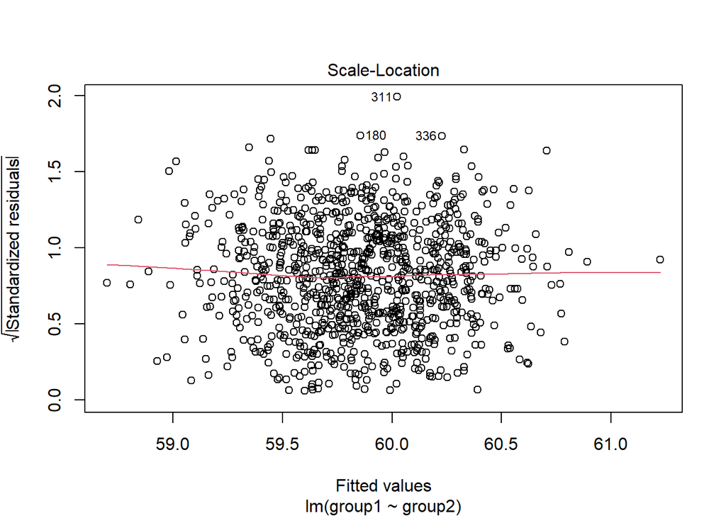

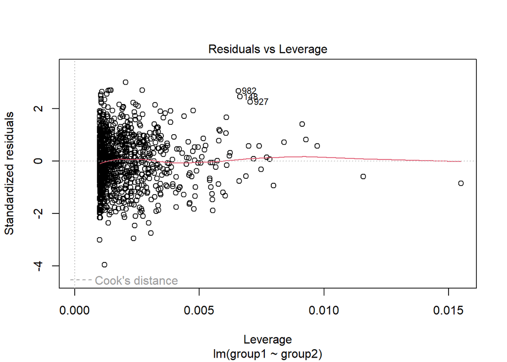

```r
Y<-lm(group1~group2)
plot(Y)
```

### Question 2

**14 points**

Obtain a copy of the [football-values lecture](https://github.com/couthcommander/football-values). Save the `2021/proj_wr21.csv` file in your working directory. Read in the data set and remove the first two columns.

```r
library(dplyr)
d_original <- read.csv("proj_wr21.csv")
data_remove_2_columns <- d_original %>% dplyr::select(-c(1, 2))
data_remove_2_columns
```

```
##     rec_att rec_yds rec_tds rush_att rush_yds rush_tds fumbles  fpts
## 1     100.2  1436.2    12.3     12.9     82.4      0.8     0.7 229.2
## 2     122.5  1462.5    12.8      0.0      0.0      0.0     0.8 221.3
## 3     113.5  1474.5     9.3      2.4     15.6      0.1     1.2 202.4
## 4      99.3  1415.3     8.8      4.6     26.2      0.1     0.8 196.1
## 5     122.1  1467.7     7.6      0.9      4.4      0.0     1.5 190.2
## 6      86.6  1301.3     9.9      0.3      1.3      0.0     1.4 187.2
## 7      93.5  1392.3     7.9      0.4      1.5      0.0     0.8 185.2
## 8      84.5  1267.9     9.8      0.5      7.5      0.0     0.9 184.5
## 9     111.2  1208.6     7.9      3.0     16.3      0.1     1.0 168.4
## 10     76.1  1113.5     9.4      0.0      0.0      0.0     0.7 166.5
## 11     91.5  1235.7     6.5      1.8     12.1      0.1     0.7 162.9
## 12     98.3  1223.4     6.9      0.3      0.3      0.0     0.7 162.6
## 13     89.8  1187.7     7.2      2.6     11.7      0.0     0.7 161.9
## 14     79.6  1021.5     9.2      3.2     14.6      0.3     0.7 158.9
```

[output cut: 228 more lines]

1. Show the correlation matrix of this data set. (4 points)

```r
data_remove_2_columns.cor<- cor(data_remove_2_columns)
data_remove_2_columns.cor
```

```
##            rec_att   rec_yds   rec_tds  rush_att  rush_yds  rush_tds   fumbles
## rec_att  1.0000000 0.9889836 0.9620513 0.2242480 0.2810831 0.2312038 0.6423627
## rec_yds  0.9889836 1.0000000 0.9720400 0.2062038 0.2614786 0.2115013 0.6487247
## rec_tds  0.9620513 0.9720400 1.0000000 0.2004448 0.2540571 0.2151580 0.6021914
## rush_att 0.2242480 0.2062038 0.2004448 1.0000000 0.9779751 0.9308512 0.1446322
## rush_yds 0.2810831 0.2614786 0.2540571 0.9779751 1.0000000 0.9298581 0.1761579
## rush_tds 0.2312038 0.2115013 0.2151580 0.9308512 0.9298581 1.0000000 0.1809564
## fumbles  0.6423627 0.6487247 0.6021914 0.1446322 0.1761579 0.1809564 1.0000000
## fpts     0.9863078 0.9957911 0.9842850 0.2610623 0.3162080 0.2677821 0.6288445
##               fpts
## rec_att  0.9863078
## rec_yds  0.9957911
## rec_tds  0.9842850
## rush_att 0.2610623
## rush_yds 0.3162080
## rush_tds 0.2677821
## fumbles  0.6288445
## fpts     1.0000000
```

```r
head(data_remove_2_columns.cor)
```

```
##            rec_att   rec_yds   rec_tds  rush_att  rush_yds  rush_tds   fumbles
## rec_att  1.0000000 0.9889836 0.9620513 0.2242480 0.2810831 0.2312038 0.6423627
## rec_yds  0.9889836 1.0000000 0.9720400 0.2062038 0.2614786 0.2115013 0.6487247
## rec_tds  0.9620513 0.9720400 1.0000000 0.2004448 0.2540571 0.2151580 0.6021914
## rush_att 0.2242480 0.2062038 0.2004448 1.0000000 0.9779751 0.9308512 0.1446322
## rush_yds 0.2810831 0.2614786 0.2540571 0.9779751 1.0000000 0.9298581 0.1761579
## rush_tds 0.2312038 0.2115013 0.2151580 0.9308512 0.9298581 1.0000000 0.1809564
##               fpts
## rec_att  0.9863078
## rec_yds  0.9957911
## rec_tds  0.9842850
## rush_att 0.2610623
## rush_yds 0.3162080
## rush_tds 0.2677821
```

1. Generate a data set with 30 rows that has a similar correlation structure. Repeat the procedure 1,000 times and return the mean correlation matrix. (10 points)

```r
library(MASS)
(data_remove_2_columns.cor<- cor(data_remove_2_columns))
```

```
##            rec_att   rec_yds   rec_tds  rush_att  rush_yds  rush_tds   fumbles
## rec_att  1.0000000 0.9889836 0.9620513 0.2242480 0.2810831 0.2312038 0.6423627
## rec_yds  0.9889836 1.0000000 0.9720400 0.2062038 0.2614786 0.2115013 0.6487247
## rec_tds  0.9620513 0.9720400 1.0000000 0.2004448 0.2540571 0.2151580 0.6021914
## rush_att 0.2242480 0.2062038 0.2004448 1.0000000 0.9779751 0.9308512 0.1446322
## rush_yds 0.2810831 0.2614786 0.2540571 0.9779751 1.0000000 0.9298581 0.1761579
## rush_tds 0.2312038 0.2115013 0.2151580 0.9308512 0.9298581 1.0000000 0.1809564
## fumbles  0.6423627 0.6487247 0.6021914 0.1446322 0.1761579 0.1809564 1.0000000
## fpts     0.9863078 0.9957911 0.9842850 0.2610623 0.3162080 0.2677821 0.6288445
##               fpts
## rec_att  0.9863078
## rec_yds  0.9957911
## rec_tds  0.9842850
## rush_att 0.2610623
## rush_yds 0.3162080
## rush_tds 0.2677821
## fumbles  0.6288445
## fpts     1.0000000
```

```r
(vcov.data=var(data_remove_2_columns))
```

```
##               rec_att      rec_yds      rec_tds    rush_att    rush_yds
## rec_att    981.061929  12584.34292   81.4242996  32.4572117  204.588076
## rec_yds  12584.342918 165038.96991 1067.0505428 387.1010445 2468.463561
## rec_tds     81.424300   1067.05054    7.3015521   2.5028610   15.952776
## rush_att    32.457212    387.10104    2.5028610  21.3534853  105.016988
## rush_yds   204.588076   2468.46356   15.9527763 105.0169879  540.001266
## rush_tds     1.397735     16.58395    0.1122139   0.8302260    4.170573
## fumbles     10.268491    134.50294    0.8304629   0.3410967    2.089189
## fpts      1755.690737  22990.52352  151.1526635  68.5592157  417.597227
##             rush_tds      fumbles         fpts
## rec_att   1.39773533  10.26849079  1755.690737
## rec_yds  16.58395254 134.50294400 22990.523520
## rec_tds   0.11221392   0.83046295   151.152663
## rush_att  0.83022599   0.34109667    68.559216
## rush_yds  4.17057337   2.08918899   417.597227
## rush_tds  0.03725318   0.01782518     2.937315
## fumbles   0.01782518   0.26046912    18.239323
## fpts      2.93731491  18.23932307  3229.793179
```

```r
(means.data=colMeans(data_remove_2_columns))
```

```
##     rec_att     rec_yds     rec_tds    rush_att    rush_yds    rush_tds
##  31.0198347 399.3826446   2.5049587   1.6004132   8.9590909   0.0553719
##     fumbles        fpts
##   0.3570248  55.4900826
```

```r
o2.sim = mvrnorm(30, mu = means.data, Sigma = vcov.data)
o2.sim = as.data.frame(o2.sim)

(rho.sim=cor(o2.sim))
```

```
##            rec_att   rec_yds   rec_tds  rush_att  rush_yds  rush_tds   fumbles
## rec_att  1.0000000 0.9908372 0.9679980 0.2858097 0.3773055 0.4351396 0.5600073
## rec_yds  0.9908372 1.0000000 0.9763295 0.2569172 0.3414683 0.3976869 0.5348773
## rec_tds  0.9679980 0.9763295 1.0000000 0.2222952 0.3144965 0.3884206 0.4549562
## rush_att 0.2858097 0.2569172 0.2222952 1.0000000 0.9828004 0.9035686 0.2568722
## rush_yds 0.3773055 0.3414683 0.3144965 0.9828004 1.0000000 0.9301721 0.3088719
## rush_tds 0.4351396 0.3976869 0.3884206 0.9035686 0.9301721 1.0000000 0.3191319
## fumbles  0.5600073 0.5348773 0.4549562 0.2568722 0.3088719 0.3191319 1.0000000
## fpts     0.9891752 0.9966407 0.9869506 0.2938732 0.3800117 0.4394181 0.5076182
##               fpts
## rec_att  0.9891752
## rec_yds  0.9966407
## rec_tds  0.9869506
## rush_att 0.2938732
## rush_yds 0.3800117
## rush_tds 0.4394181
## fumbles  0.5076182
## fpts     1.0000000
```

```r
keep.1=0
loops=10000

for (i in 1:loops) {
  o2.sim = mvrnorm(30, mu = means.data, Sigma = vcov.data)
  keep.1=keep.1+cor(o2.sim)/loops   # Sneaky way to take average as it accumulates
}
keep.1
```

```
##            rec_att   rec_yds   rec_tds  rush_att  rush_yds  rush_tds   fumbles
## rec_att  1.0000000 0.9884862 0.9604686 0.2193719 0.2749891 0.2273552 0.6350057
## rec_yds  0.9884862 1.0000000 0.9708148 0.2012052 0.2552343 0.2076235 0.6416084
## rec_tds  0.9604686 0.9708148 1.0000000 0.1958487 0.2480436 0.2113667 0.5946825
## rush_att 0.2193719 0.2012052 0.1958487 1.0000000 0.9773528 0.9289365 0.1410645
## rush_yds 0.2749891 0.2552343 0.2480436 0.9773528 1.0000000 0.9279537 0.1716198
## rush_tds 0.2273552 0.2076235 0.2113667 0.9289365 0.9279537 1.0000000 0.1773901
## fumbles  0.6350057 0.6416084 0.5946825 0.1410645 0.1716198 0.1773901 1.0000000
## fpts     0.9857333 0.9955982 0.9835857 0.2555933 0.3095233 0.2633682 0.6215973
##               fpts
## rec_att  0.9857333
## rec_yds  0.9955982
## rec_tds  0.9835857
## rush_att 0.2555933
## rush_yds 0.3095233
## rush_tds 0.2633682
## fumbles  0.6215973
## fpts     1.0000000
```

```r
colMeans(keep.1)
```

```
##   rec_att   rec_yds   rec_tds  rush_att  rush_yds  rush_tds   fumbles      fpts
## 0.6614262 0.6575713 0.6456013 0.4899216 0.5205896 0.4929992 0.4978710 0.6768749
```

```r
data_remove_2_columns.cor ;
```

```
##            rec_att   rec_yds   rec_tds  rush_att  rush_yds  rush_tds   fumbles
## rec_att  1.0000000 0.9889836 0.9620513 0.2242480 0.2810831 0.2312038 0.6423627
## rec_yds  0.9889836 1.0000000 0.9720400 0.2062038 0.2614786 0.2115013 0.6487247
## rec_tds  0.9620513 0.9720400 1.0000000 0.2004448 0.2540571 0.2151580 0.6021914
## rush_att 0.2242480 0.2062038 0.2004448 1.0000000 0.9779751 0.9308512 0.1446322
## rush_yds 0.2810831 0.2614786 0.2540571 0.9779751 1.0000000 0.9298581 0.1761579
## rush_tds 0.2312038 0.2115013 0.2151580 0.9308512 0.9298581 1.0000000 0.1809564
## fumbles  0.6423627 0.6487247 0.6021914 0.1446322 0.1761579 0.1809564 1.0000000
## fpts     0.9863078 0.9957911 0.9842850 0.2610623 0.3162080 0.2677821 0.6288445
##               fpts
## rec_att  0.9863078
## rec_yds  0.9957911
## rec_tds  0.9842850
## rush_att 0.2610623
## rush_yds 0.3162080
## rush_tds 0.2677821
## fumbles  0.6288445
## fpts     1.0000000
```

```r
        # and the difference can be further reduced by increasing 'loops'

data_remove_2_columns.cor: colMeans(keep.1)
```

```
## [1] 1
```

### Question 3

**21 points**

Here’s some code:

```r
nDist <- function(n = 100) {
  df <- 10
  prob <- 1/3
  shape <- 1
  size <- 16
  list(
    beta = rbeta(n, shape1 = 5, shape2 = 45),
    binomial = rbinom(n, size, prob),
    chisquared = rchisq(n, df),
    exponential = rexp(n),
    f = rf(n, df1 = 11, df2 = 17),
    gamma = rgamma(n, shape),
    geometric = rgeom(n, prob),
    hypergeometric = rhyper(n, m = 50, n = 100, k = 8),
    lognormal = rlnorm(n),
    negbinomial = rnbinom(n, size, prob),
    normal = rnorm(n),
    poisson = rpois(n, lambda = 25),
    t = rt(n, df),
    uniform = runif(n),
    weibull = rweibull(n, shape)
  )
}
```

1. What does this do? (3 points)

```r
round(sapply(nDist(5000), mean), 2)
```

```
##           beta       binomial     chisquared    exponential              f
##           0.10           5.27           9.90           1.05           1.13
##          gamma      geometric hypergeometric      lognormal    negbinomial
##           1.01           1.96           2.64           1.67          31.92
##         normal        poisson              t        uniform        weibull
##           0.01          25.08           0.00           0.50           1.00
```

[output not shown]

1. What about this? (3 points)

```r
sort(apply(replicate(20, round(sapply(nDist(10000), mean), 2)), 1, sd))
```

```
##           beta        uniform              f        weibull         normal
##    0.000000000    0.004588315    0.006048053    0.009445132    0.009880869
##    exponential          gamma hypergeometric              t      geometric
##    0.010208356    0.010310955    0.010563094    0.011909748    0.016827296
##       binomial      lognormal        poisson     chisquared    negbinomial
##    0.020287409    0.023902213    0.042781575    0.047183851    0.111651478
```

[output not shown]

In the output above, a small value would indicate that `N=10,000` would provide a sufficent sample size as to estimate the mean of the distribution. Let’s say that a value *less than 0.02* is “close enough”.

1. For each distribution, estimate the sample size required to simulate the distribution’s mean. (15 points)

Don’t worry about being exact. It should already be clear that N < 10,000 for many of the distributions. You don’t have to show your work. Put your answer to the right of the vertical bars (`|`) below.

[output not shown]